# New York Giants Offense: Scouting Report

**Public data.** Built from nflverse (nflfastR play-by-play, NGS participation, FTN charting), mapped onto the PFF GamePBP layout. Run concepts, PFF success codes, yards after contact and receiver alignment are not in this source; see *What nflverse cannot cover* at the end.

**Sample:** 8 games (Sep 13, 2026 to Nov 08, 2026) · 515 offensive plays · Opponents: ARZ, DAL, HST, LA, NO, PHI, TEN, WAS  
**Source:** NYG_2026_nflverse_GamePBP.csv · Generated Nov 10, 2026 18:07 · Success = standard yardage definition · EPA = nflfastR model

58%Pass rate

51%Neutral early-down pass rate

+0.00EPA / play

44%Success rate

42%3rd-down conversion

9%Sack rate

8%Explosive play rate

## Key findings

### Tendencies

- Passes on 58% of all plays and 51% of neutral early-down plays (1st/2nd down, outside 2-minute drills).
- QB alignment is a strong run/pass key: under center they run 71% of the time (n=192); in shotgun they pass 80% (n=306).
- Pistol is a real part of the menu: 17 plays, 6% pass.
- Tell: 3rd Down + Medium (4-6) -> pass 100% of the time (n=20, 95% lower bound 84%).
- Tell: 3rd Down + Long (7-10) -> pass 95% of the time (n=37, 95% lower bound 82%).
- Tell: 3rd Down + Extra Long (11+) -> pass 96% of the time (n=26, 95% lower bound 81%).
- Tell: Shotgun + 3rd Down -> pass 85% of the time (n=101, 95% lower bound 77%).
- Run game is built on Middle and Left Guard: 45% of carries.
- Predictability: knowing personnel, alignment, down and distance lifts a defense’s run/pass guess from 58% to 79% (leave-one-out).

### Strengths

- Most efficient run gap: Left End, +0.10 EPA/carry, 5.1 YPC, 56% success (n=27).
- Primary target: M. Nabers (#1) (WR), 30% target share, 53 catches for 648 yards, +0.23 EPA/target, 29 first downs.
- Most efficient receiver: T. Tracy Jr. (#29) (HB), +0.64 EPA/target on 7 targets, aDOT 0.6, 10.8 YAC/rec.
- Lead back C. Skattebo (#44): 46% of carries, 4.3 YPC, 46% success. Favorite gap: Middle.
- Most total value: M. Nabers (#1), 18.1 total EPA on 78 touches + targets (648 scrimmage yards).
- Deep shots (20+ air yards): 16% of targets, 39% complete, +0.59 EPA/target (n=41).

### Vulnerabilities

- Play action: 21% of dropbacks, -0.05 EPA/play vs +0.12 without (n=63 vs 238).
- Least efficient run gap: Right Tackle, -0.56 EPA/carry, stuffed (0 or fewer yards) on 31% (n=16).
- On 3rd and Extra Long (11+) they convert only 23% (n=26); they pass 96% of the time there. Overall 3rd-down conversion: 42%.

**n** = the number of plays (or carries / targets) behind a number, i.e. the sample size. Findings are generated by fixed rules (see Methodology) and include sample sizes. Treat any rate built on fewer than 10 plays as anecdotal.

## 1. Personnel run/pass tendencies

[figure not shown]

Not available for this data set.

515 plays with no recorded personnel are left out of this section.

## 2. Down-and-distance tendencies

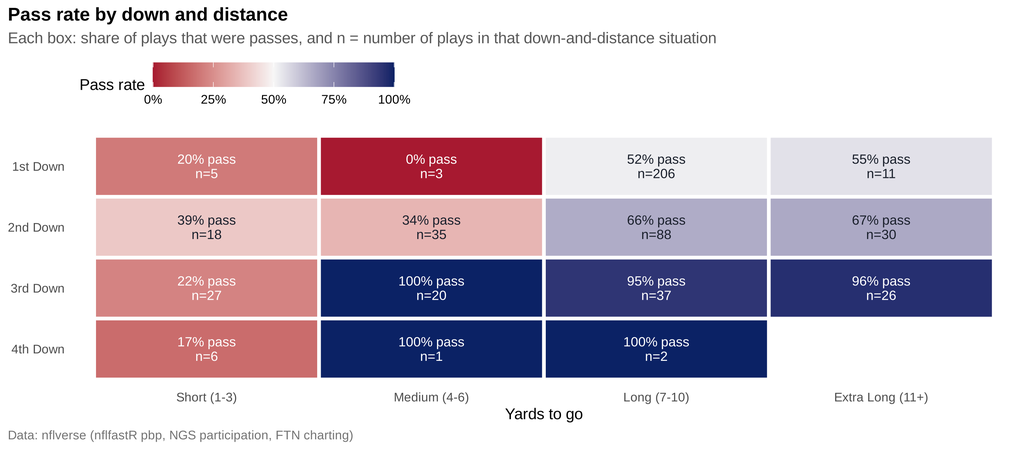

| Down | To go | Plays | Pass % | Run EPA | Pass EPA | Success |
| --- | --- | --- | --- | --- | --- | --- |
| 1st Down | Short (1-3) | 5 | 20% | +0.06 | -0.27 | 40% |
| 1st Down | Medium (4-6) | 3 | 0% | -0.67 | n/a | 33% |
| 1st Down | Long (7-10) | 206 | 52% | -0.14 | +0.10 | 45% |
| 1st Down | Extra Long (11+) | 11 | 55% | -0.21 | +0.09 | 27% |
| 2nd Down | Short (1-3) | 18 | 39% | +0.35 | -0.66 | 78% |
| 2nd Down | Medium (4-6) | 35 | 34% | -0.11 | +0.29 | 54% |
| 2nd Down | Long (7-10) | 88 | 66% | -0.45 | +0.09 | 40% |
| 2nd Down | Extra Long (11+) | 30 | 67% | -0.43 | +0.02 | 30% |
| 3rd Down | Short (1-3) | 27 | 22% | +0.00 | +0.25 | 63% |
| 3rd Down | Medium (4-6) | 20 | 100% | n/a | +0.78 | 60% |
| 3rd Down | Long (7-10) | 37 | 95% | -0.86 | -0.44 | 30% |
| 3rd Down | Extra Long (11+) | 26 | 96% | -0.31 | +0.20 | 23% |
| 4th Down | Short (1-3) | 6 | 17% | +2.11 | -2.58 | 83% |
| 4th Down | Medium (4-6) | 1 | 100% | n/a | +4.39 | 100% |
| 4th Down | Long (7-10) | 2 | 100% | n/a | +0.68 | 50% |

**By field position** (yards from the opponent’s end zone):

| Zone | Plays | Pass % | EPA/play | Success |
| --- | --- | --- | --- | --- |
| Goal to Go (1-10) | 21 | 33% | +0.15 | 52% |
| Red Zone (11-20) | 37 | 59% | +0.27 | 41% |
| Plus Territory (21-50) | 202 | 57% | -0.10 | 41% |
| Own Territory (51-80) | 215 | 63% | +0.02 | 47% |
| Backed Up (81-99) | 40 | 52% | +0.09 | 48% |

## 3. QB alignment tendencies

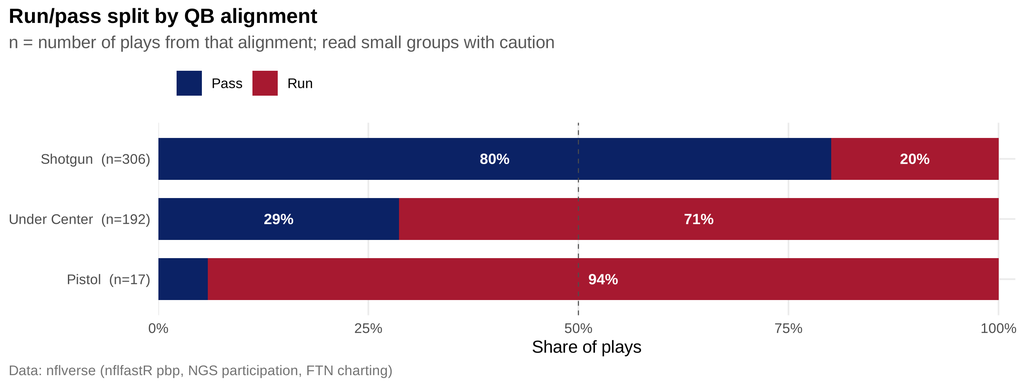

| Alignment | Plays | Snap % | Pass % | Run EPA | Pass EPA | Run YPC | Pass Y/P |
| --- | --- | --- | --- | --- | --- | --- | --- |
| Under Center | 192 | 37% | 29% | -0.12 | +0.04 | 3.5 | 6.1 |
| Shotgun | 306 | 59% | 80% | -0.13 | +0.09 | 3.8 | 6.3 |
| Pistol | 17 | 3% | 6% | -0.02 | +0.70 | 5.0 | 9.0 |

**Alignment by personnel** (groupings with enough plays):

Not available for this data set.

## 4. Run gap and direction: frequency and effectiveness

nflverse does not chart blocking schemes, so runs are grouped by the gap and side the play-by-play records (end / tackle / guard / middle). This answers *where* they run, not *which concept*.

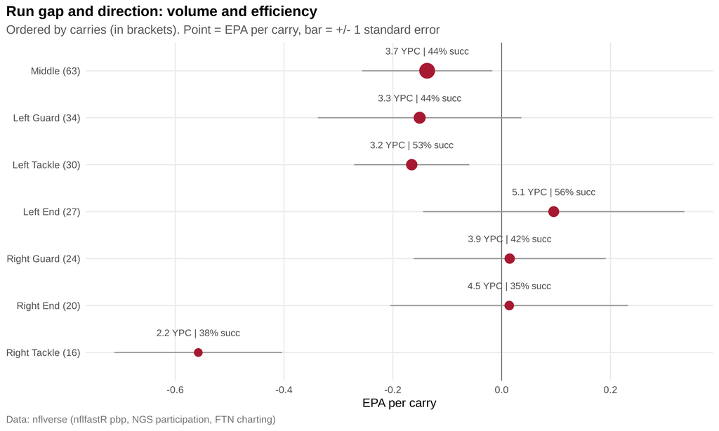

| Concept | Carries | Share | YPC | Median | Success | EPA/carry | Stuff % | Explosive % | Under center % | Top personnel |
| --- | --- | --- | --- | --- | --- | --- | --- | --- | --- | --- |
| Middle | 63 | 29% | 3.7 | 2.0 | 44% | -0.14 | 19% | 6% | 63% | Unknown |
| Left Guard | 34 | 16% | 3.3 | 3.0 | 44% | -0.15 | 15% | 3% | 68% | Unknown |
| Left Tackle | 30 | 14% | 3.2 | 3.0 | 53% | -0.17 | 17% | 0% | 80% | Unknown |
| Left End | 27 | 13% | 5.1 | 3.0 | 56% | +0.10 | 19% | 19% | 44% | Unknown |
| Right Guard | 24 | 11% | 3.9 | 3.0 | 42% | +0.01 | 12% | 8% | 62% | Unknown |
| Right End | 20 | 9% | 4.5 | 2.5 | 35% | +0.01 | 20% | 15% | 55% | Unknown |
| Right Tackle | 16 | 7% | 2.2 | 3.0 | 38% | -0.56 | 31% | 0% | 75% | Unknown |

## 5. Third-down behavior and key targets

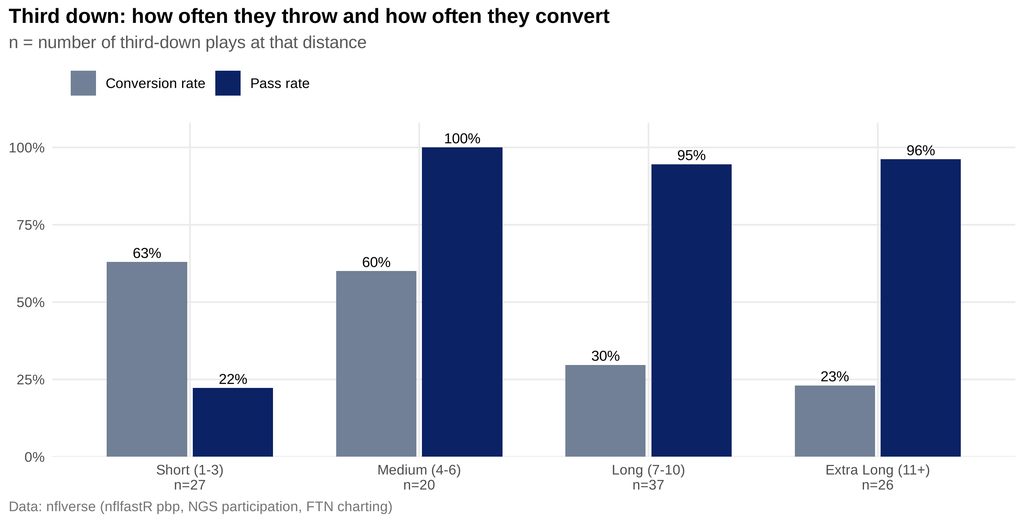

| To go | Plays | Pass % | Conv % | Conv 95% CI | EPA/play | Gun/Pistol % | Avg air yds | Sack % |
| --- | --- | --- | --- | --- | --- | --- | --- | --- |
| Short (1-3) | 27 | 22% | 63% | 44%-78% | +0.06 | 70% | 3.8 | 17% |
| Medium (4-6) | 20 | 100% | 60% | 39%-78% | +0.78 | 100% | 9.1 | 15% |
| Long (7-10) | 37 | 95% | 30% | 17%-46% | -0.46 | 97% | 13.9 | 17% |
| Extra Long (11+) | 26 | 96% | 23% | 11%-42% | +0.18 | 100% | 11.5 | 4% |

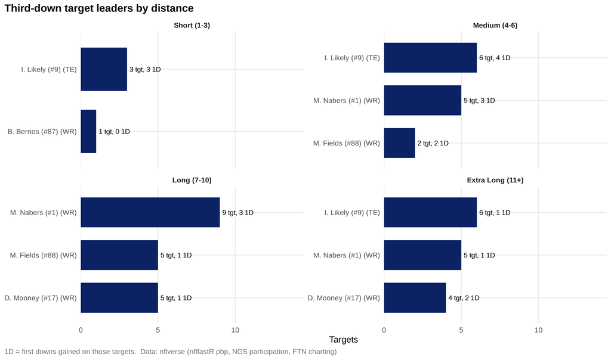

All third downs

| Player | Pos | Targets | Share | Rec | Yds | 1st downs | EPA/tgt | aDOT |
| --- | --- | --- | --- | --- | --- | --- | --- | --- |
| M. Nabers (#1) | WR | 19 | 27% | 11 | 142 | 7 | +0.00 | 14.4 |
| I. Likely (#9) | TE | 18 | 25% | 14 | 160 | 10 | +0.60 | 8.2 |
| D. Mooney (#17) | WR | 10 | 14% | 4 | 52 | 3 | +0.11 | 14.5 |
| M. Fields (#88) | WR | 10 | 14% | 6 | 111 | 5 | +0.63 | 19.0 |
| D. Singletary (#26) | HB | 6 | 8% | 5 | 39 | 2 | +0.23 | -1.5 |
| C. Skattebo (#44) | HB | 3 | 4% | 3 | 45 | 2 | +1.30 | 9.7 |
| T. Tracy Jr. (#29) | HB | 3 | 4% | 3 | 31 | 1 | +0.54 | 2.0 |
| B. Berrios (#87) | WR | 1 | 1% | 0 | 0 | 0 | -1.43 | 3.0 |

## 6. Most effective players and how they produce

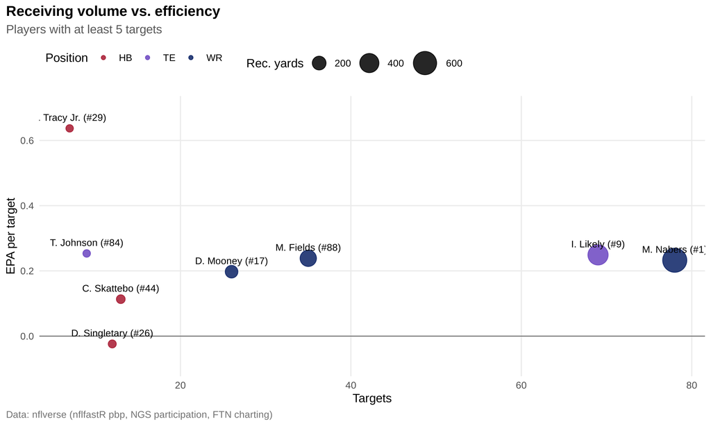

| Player | Pos | Tgt | Share | Rec | Yds | Catch % | Y/Tgt | aDOT | YAC/Rec | EPA/Tgt | 1D |
| --- | --- | --- | --- | --- | --- | --- | --- | --- | --- | --- | --- |
| M. Nabers (#1) | WR | 78 | 30% | 53 | 648 | 68% | 8.3 | 11.4 | 3.2 | +0.23 | 29 |
| I. Likely (#9) | TE | 69 | 27% | 46 | 448 | 67% | 6.5 | 7.6 | 3.3 | +0.25 | 27 |
| M. Fields (#88) | WR | 35 | 13% | 19 | 288 | 54% | 8.2 | 13.5 | 5.5 | +0.24 | 13 |
| D. Mooney (#17) | WR | 26 | 10% | 12 | 167 | 46% | 6.4 | 13.8 | 3.4 | +0.20 | 8 |
| C. Skattebo (#44) | HB | 13 | 5% | 11 | 76 | 85% | 5.8 | 1.8 | 5.1 | +0.11 | 3 |
| D. Singletary (#26) | HB | 12 | 5% | 10 | 63 | 83% | 5.2 | -2.3 | 9.2 | -0.02 | 3 |
| T. Johnson (#84) | TE | 9 | 3% | 4 | 55 | 44% | 6.1 | 10.8 | 4.8 | +0.25 | 3 |
| T. Tracy Jr. (#29) | HB | 7 | 3% | 5 | 54 | 71% | 7.7 | 0.6 | 10.8 | +0.64 | 2 |
| C. Jones (#89) | WR | 3 | 1% | 2 | 66 | 67% | 22.0 | 23.7 | 0.0 | +1.41 | 1 |
| P. Ricard (#45) | HB | 3 | 1% | 1 | 1 | 33% | 0.3 | -0.3 | 0.0 | -0.60 | 0 |
| B. Berrios (#87) | WR | 1 | 0% | 0 | 0 | 0% | 0.0 | 3.0 | n/a | -1.43 | 0 |
| J. Hyatt (#81) | WR | 1 | 0% | 0 | 0 | 0% | 0.0 | 46.0 | n/a | -0.57 | 0 |

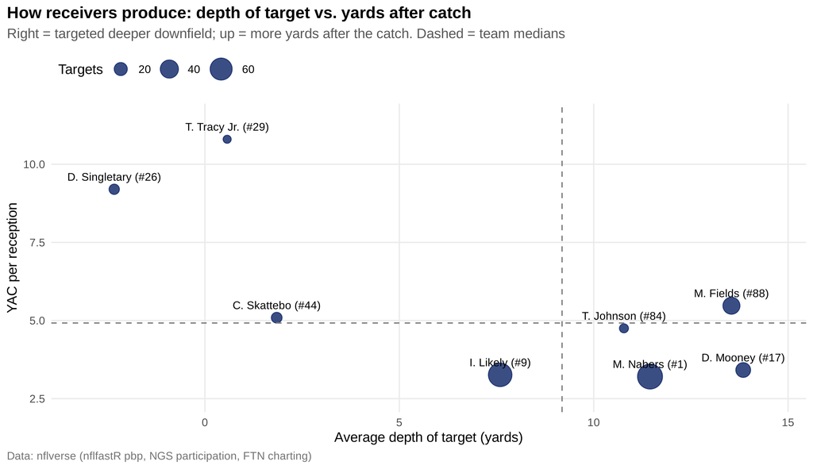

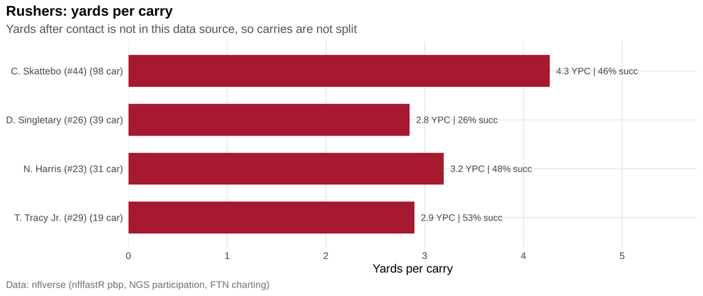

| Player | Carries | Share | Yds | YPC | Success | EPA/car | YBC | YACo | Explosive % | Stuff % | Top concept |
| --- | --- | --- | --- | --- | --- | --- | --- | --- | --- | --- | --- |
| C. Skattebo (#44) | 98 | 46% | 418 | 4.3 | 46% | -0.11 | n/a | n/a | 9% | 14% | Middle |
| D. Singletary (#26) | 39 | 18% | 111 | 2.8 | 26% | -0.29 | n/a | n/a | 5% | 26% | Middle |
| N. Harris (#23) | 31 | 14% | 99 | 3.2 | 48% | -0.40 | n/a | n/a | 3% | 16% | Left Guard |
| T. Tracy Jr. (#29) | 19 | 9% | 55 | 2.9 | 53% | -0.24 | n/a | n/a | 0% | 26% | Left End |
| J. Winston (#19) | 9 | 4% | 11 | 1.2 | 78% | +0.87 | n/a | n/a | 0% | 22% | Middle |
| J. Dart (#6) | 6 | 3% | 49 | 8.2 | 83% | +1.06 | n/a | n/a | 33% | 0% | Left End |
| J. McCarthy (#18) | 5 | 2% | 4 | 0.8 | 0% | -1.00 | n/a | n/a | 0% | 40% | Left End |
| D. Mooney (#17) | 4 | 2% | 28 | 7.0 | 75% | +1.09 | n/a | n/a | 25% | 25% | Left End |

**Total offensive value** (rushing + receiving EPA; QB passing EPA is credited to targets):

| Player | Carries | Targets | Scrimmage yds | Rush EPA | Rec EPA | Total EPA | EPA/opp |
| --- | --- | --- | --- | --- | --- | --- | --- |
| M. Nabers (#1) | 0 | 78 | 648 | 0.0 | 18.1 | 18.1 | +0.23 |
| I. Likely (#9) | 0 | 69 | 448 | 0.0 | 17.2 | 17.2 | +0.25 |
| D. Mooney (#17) | 4 | 26 | 195 | 4.4 | 5.1 | 9.5 | +0.32 |
| M. Fields (#88) | 0 | 35 | 288 | 0.0 | 8.4 | 8.4 | +0.24 |
| J. Winston (#19) | 9 | 0 | 11 | 7.8 | 0.0 | 7.8 | +0.87 |
| J. Dart (#6) | 6 | 0 | 49 | 6.3 | 0.0 | 6.3 | +1.06 |
| C. Jones (#89) | 0 | 3 | 66 | 0.0 | 4.2 | 4.2 | +1.41 |
| T. Fidone II (#86) | 0 | 1 | 29 | 0.0 | 2.4 | 2.4 | +2.44 |

## 7. Passing-game context

| Split | Value | Dropbacks | Share | EPA/play | Success | Y/P |
| --- | --- | --- | --- | --- | --- | --- |
| Play action | No | 238 | 79% | +0.12 | 44% | 6.5 |
| Play action | Yes | 63 | 21% | -0.05 | 43% | 5.1 |
| Screen | No | 283 | 94% | +0.12 | 45% | 6.5 |
| Screen | Yes | 18 | 6% | -0.45 | 33% | 2.4 |

Targets by depth

| Depth | Targets | Share | Comp % | Y/Tgt | EPA/Tgt | INT % |
| --- | --- | --- | --- | --- | --- | --- |
| Behind LOS | 48 | 18% | 79% | 3.8 | -0.13 | 0% |
| Short (1-9) | 104 | 40% | 70% | 5.3 | +0.09 | 1% |
| Intermediate (10-19) | 67 | 26% | 57% | 9.8 | +0.47 | 7% |
| Deep (20+) | 41 | 16% | 39% | 12.4 | +0.59 | 0% |

Results by defensive coverage faced (5+ dropbacks)

| Coverage | Dropbacks | Share | EPA/play | Success |
| --- | --- | --- | --- | --- |
| Unknown | 301 | 100% | +0.09 | 44% |

## 8. Pre-snap tells and predictability

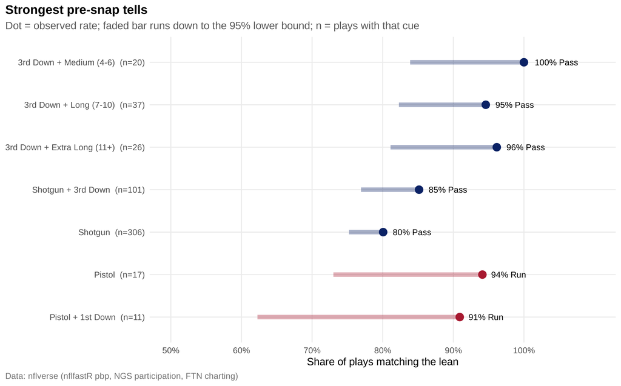

Always guessing the more common play type is right **58%** of the time. Using personnel, alignment, down and distance bucket (leave-one-out cell rates) is right **79%** of the time, a lift of **21%**.

## Methodology and data notes

How the sample was built

| Step | Plays |
| --- | --- |
| Offensive snaps in file | 579 |
| Run or pass plays (drops penalties / no-plays) | 527 |
| Downs 1-4 (drops PATs / 2-pt tries) | 527 |
| Excluding garbage time | 527 |
| Excluding QB kneels and spikes | 515 |

### What nflverse cannot cover (or only approximates)

- Personnel / formation / coverage / routes: nflverse participation data covers only 0% of these plays (it is typically posted after the season), so those sections are mostly empty.
- Run concepts: nflverse has no blocking-scheme charting (inside zone, duo, power …). Section 4 groups runs by gap and direction instead (e.g. ‘Left Tackle’, ‘Middle’).
- PFF success codes (pff_OFFSUCCESS): not in nflverse. Success uses the standard 40/60/100 yardage rule only.
- EPA / EP: nflfastR’s public model, not PFF’s. Values are close in spirit but not identical.
- Yards after contact: not in nflverse, so the before/after-contact split for rushers is unavailable (yards per carry is shown instead).
- Receiver alignment (slot / wide / backfield): not in nflverse. ‘Main align’ is blank.
- Personnel is counted from the roster positions of the 11 players on the field (RB+FB, TE). A WR listed as TE on the roster counts as a TE. ’(*)’ = 6+ offensive linemen.
- Garbage time is approximated with win probability (second half, pre-snap WP below 0.01% or above 99.99%). Calibrated against a licensed PFF sample.
- 2-minute flag: inside the final 2:00 of either half (PFF’s 4-minute flag has no equivalent).
- Pressure is NGS ‘was_pressure’ (yes/no); time to pressure is not available.

Column names below refer to the PFF GamePBP layout the nflverse data was mapped onto.

- **Pass play / dropback:** `pff_RUNPASS = "P"`, which includes sacks and QB scrambles. **Run:** `"R"`. Penalties and no-plays (`"X"`) are removed.
- **QB alignment:** Pistol if `pff_PISTOL` is set, otherwise Shotgun if `pff_SHOTGUN` is set, otherwise Under Center.
- **Success (standard):** gaining at least 40% of the distance on 1st down, 60% on 2nd, and 100% on 3rd/4th, or earning a first down. PFF success codes are not in nflverse, so only the standard rule is used.
- **First down:** `pff_FIRSTDOWNGAINED = 1` or yards gained ≥ distance.
- **EPA:** `pff_EXPECTEDPOINTSADDED` as provided. Passing EPA is attributed to the targeted receiver.
- **Target:** a pass play with a recorded receiver, excluding sacks and scrambles. **Receiving yards:** yards gained on completions.
- **Explosive:** runs of 10+ yards, passes of 20+ yards.
- **Field zone:** `ABSOLUTEYARDLINE` is yards to the opponent’s end zone (so 1–20 is the red zone).
- **Tell:** a pre-snap cue (personnel, alignment, down, distance, or combinations) with at least 10 plays where one play type reaches 80%. The 95% lower bound uses a Wilson interval.
- **Intervals:** rates show 95% Wilson intervals; run-concept EPA shows ±1 standard error. With samples this small, most differences between groups are not statistically distinguishable; the report shows n everywhere so readers can judge.
- **Garbage time** excluded: TRUE. **2-minute drills** excluded: FALSE. **Personnel “(*)“** marks a jumbo package (an extra offensive lineman replaces a skill player); merged into the base grouping: FALSE.

**Data checks:**

- Player names from NYG_2026_roster.csv (nflverse weekly rosters 2026)

Blank numeric cells (for example yards after catch on runs) are expected and listed for completeness.

Reproducibility: source file MD5 6f5019982e4490a37f8fe2b51a6dbf45. Every table in this report is also saved as CSV and in one Excel workbook next to this file.